# Artificial Neural Networks > Fitting

*Alípio Jorge*

May 2021

# Training ANN > summary

- Also called **fitting** or **learning**
  - The parameters to **learn** are the weights
  - The number of parameters can be large
  - The relationship between the data and the parameters is **complex**
  - There is **no analytical solution** (in general)
  - We need a **search procedure**

# Training ANN

- The loss function to **minimize**:
  - SSE - sum of squared errors, for regression
  - Cross-Entropy, for classification
- To avoid overfitting some **regularization** is used
  - we can penalize more or less the **magnitude** of the weights
- The generic search approach is **gradient based**
  - In the case of ANN, some kind of **backpropagation**

# Simple intuitive example

- Before going into backropagation
  - How to train a **perceptron**?
- Raw implementation with numpy
  - Weights $w$
  - Point $x$
  - True **class** $y$
  - **Step function**

```python
import numpy as np

x=np.array([1,-0.5,0])
w=np.array([-0.1,0.1,0.1])
y=1

def step(x):
    if x>=0:
        return 1
    else:
        return 0

yhat = step(sum(w*x))
print("y =",y,", yhat =", yhat, ", w.x =", sum(w*x))
```

```
y = 1 , yhat = 0 , w.x = -0.15000000000000002
```

# Updating the parameters

- Current $w$ gives a **wrong answer** to $x$
- We have to **change** $w$
  - the prediction needs to **get closer** to the true class
- $\hat{y} = step(w.x)$
- $w$ and $x$ are **vectors**
- $w.x$ is their inner product
  - it is **0** when $w$ and $x$ are **orthogonal**
  - it is **positive** when they are minimally aligned (less than $90^{\circ}$)
  - it is **negative** when they are not aligned (more than $90^{\circ}$)
- In the example:
  - True class is $1$, prediction is $0$
  - So, we want to make $w$ more aligned with $x$
  - One way is to **add** $x$ to $w$
    - $w_{new}=w+x$
  - $w_{new}.x=(w+x).x=w.x+x.x \ge w.x$ because $x.x$ is **always positive**
  - So, $step(w_{new}.x)$ is closer to $1$
- **What have we done?**
  - We got a **rule to update** $w$ when we have a wrong answer for class 1

```python
# update w

w=np.array([-0.1,0.1,0.1])
print("w =",w)
w = w + x
print("wnew =",w)
print("wnew.x =", sum(w*x))
print("yhat =",step(sum(w*x)))
```

```
w = [-0.1  0.1  0.1]
wnew = [ 0.9 -0.4  0.1]
wnew.x = 1.1
yhat = 1
```

# The case of class 0

- If the true class is **0**
  - We need $w.x$ to be **negative**
  - So, we make $w$ and $x$ less aligned
  - We decrease $w.x$
    - $w_{new}=w-x$
  - $w_{new}.x=(w-x).x=w.x-x.x \le w.x$ because $x.x$ is **always positive**
  - So, $step(w_{new}.x)$ is closer to $0$
- Let us now take a small dataset of size 5

```python
y=np.array([1,1,1,0,0])
X=np.array([[1,-0.5,0],
            [0.5,-1,-0.3],
            [0.5,-1,-1],
            [0,-0.5,0.1],
            [0.1,-0.3,0.8]])
X
```

```
array([[ 1. , -0.5,  0. ],
       [ 0.5, -1. , -0.3],
       [ 0.5, -1. , -1. ],
       [ 0. , -0.5,  0.1],
       [ 0.1, -0.3,  0.8]])
```

# Predict and error

- We define
  - **predict**, which takes matrices
  - **total_error**, which computes classification error

```python
def predict(X,w):
    return np.array(list(map(lambda x: step(sum(w*x)),X)))

def total_error(X,y,w):
    return 1-sum((predict(X,w)==y)*1.0)/len(y)

print("y =",y)
print("yhat =", predict(X,w))
print("Error =", total_error(X,y,w))
```

```
y = [1 1 1 0 0]
yhat = [1 1 1 1 1]
Error = 0.4
```

# Fitting

- Fitting algorithm:
  - Consider **one example at a time**
  - **Predict** a class with the current $w$
  - **Compare** with **true class**
  - If the **answer is correct** do nothing
  - **Otherwise**:
    - If true class $1$ make $w$ **more aligned** with $x$
    - If true class $0$ make $w$ **less aligned** with $x$
  - We can repeat the process for a number of **epochs**
  - Or until it **converges**

```python
w=np.array([-0.1,-0.1,-0.1])
y=np.array([1,1,1,0,0])

def fit(X,y,w):
    for i in range(X.shape[0]):
        x=X[i:(i+1),:]
        yhat=predict(x,w)[0]
        yhat
        if y[i]==1 and yhat==0:
            w=w+X[i]
        elif y[i]==0 and yhat==1:
            w=w-X[i]
    return w

print(w)
print(y)
print(predict(X,w))
print(total_error(X,y,w))

epochs=20

for i in range(epochs):
    w=fit(X,y,w)

print(w)
print(y)
print(predict(X,w))
print(total_error(X,y,w))
```

```
[-0.1 -0.1 -0.1]
[1 1 1 0 0]
[0 1 1 1 0]
0.4
[ 0.9  0.4 -0.3]
[1 1 1 0 0]
[1 1 1 0 0]
0.0
```

# Fitting

- The algorithm **converges**
  - This can be proved
- The initial $w$ is **arbitrary**
  - Can be **random** with small values around 0
  - Different initial values may make fitting more or less easy
- **Example:** Apply to a larger artificial dataset
  - With a clean linear separation

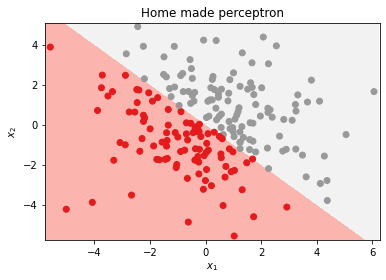

```python
from sklearn.datasets import make_blobs
import matplotlib.pyplot as plt

cmap_bg='Pastel1'
cmap_fg='Set1'

def plot_classifier_boundary(model,X,h = .05):
    # this function can be used with any sklearn classifier
    # ready for two classes but can be easily extended
    x_min, x_max = X[:, 0].min()-.2, X[:, 0].max()+.2
    y_min, y_max = X[:, 1].min()-.2, X[:, 1].max()+.2
    # generate a grid with step h
    xx, yy = np.meshgrid(np.arange(x_min, x_max, h),
                         np.arange(y_min, y_max, h))
    # the method ravel flattens xx and yy
    Z = model.predict(np.c_[xx.ravel(), yy.ravel()])
    Z = Z.reshape(xx.shape)
    plt.contourf(xx, yy, Z, cmap=cmap_bg)
    plt.xlim((x_min,x_max))
    plt.ylim((y_min,y_max))

n_points=100
std1=2
std2=1

X,y = make_blobs(n_samples=[n_points*2], centers=[(0,0)],
                 n_features=2, cluster_std=[std1],
                 random_state=1, shuffle=False)

y[X[:,0]+X[:,1]>0]=1

# define a sklearn-like class for home made perceptron
class hmper:
    def __init__(self,weights=0,bias=1,n_epochs=10,learning_rate=1):
        self.w=weights
        self.bias=bias
        self.epochs=n_epochs
        self.lr=learning_rate
    def predict(self,X):
        return np.array(list(map(
            lambda x: step(sum(self.w*x)+self.bias),
            X)))
    def fit(self,X,y):
        lr=self.lr
        for i in range(self.epochs):
            for i in range(X.shape[0]):
                x=X[i:(i+1),:]
                yhat=self.predict(x)[0]
                if y[i]==1 and yhat==0:
                    self.w=self.w+lr*X[i]
                    self.bias=self.bias+lr
                elif y[i]==0 and yhat==1:
                    self.w=self.w-lr*X[i]
                    self.bias=self.bias-lr


w=np.array([0.1,-0.1])

model=hmper(weights=w, n_epochs=20)
model.fit(X,y)

plot_classifier_boundary(model,X)

plt.scatter(X[:,0],X[:,1],c=y,cmap=cmap_fg)
plt.title('Home made perceptron')
plt.xlabel('$x_1$')
plt.ylabel('$x_2$');
```

# Fitting the perceptron > summary

- Start with **random / arbitrary weights**
- **Compare** prediction with true value
- Iteratively update weights to **improve** solution
  - In the perceptron: by changing the angle between $w$ and each $x_i$
- A **general approach** for weight updating is based on **gradients**
  - Define a **loss function** with respect to the parameters
  - **Minimize** the loss by following the gradient

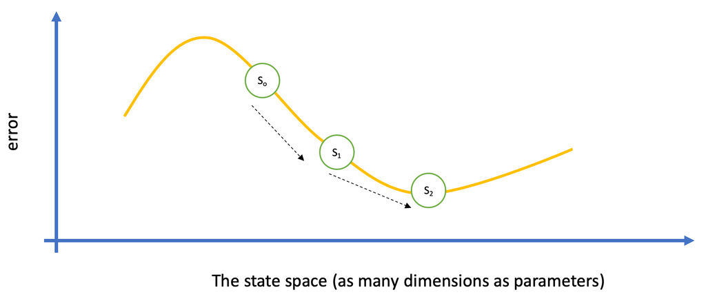

```python
from IPython.display import Image
Image("imagens/BP-search.png")
```

# MLP for Regression > 1 hidden layer

- Let us now consider MLP
- **Prediction** is **feedforward**
  - Calculate each **hidden** node value $Z_m$ from inputs $X$ $$ Z_m = h_m(X) = \sigma ( \alpha_{0m} + \alpha_m^T X) , m = 1 , . . . , M $$
  - And then each **output** layer node $T_k$ from the $Z$

$$ T_k =\beta_{0k} + \beta_k^T Z, k=1,...,K$$$$ f_k(X) = g_k(h(X)) $$

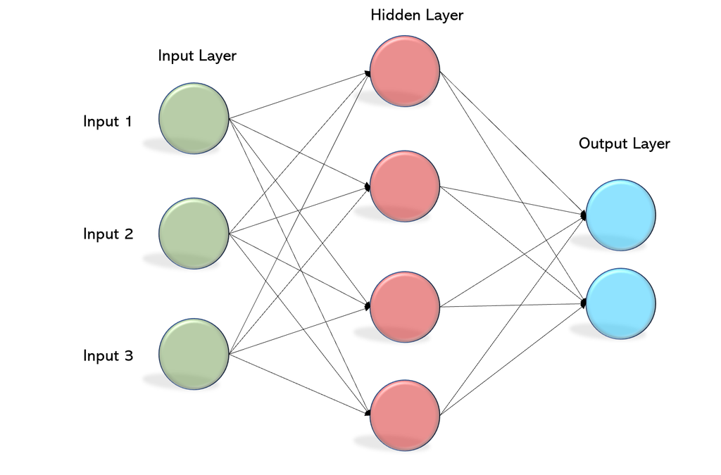

```python
from IPython.display import Image
Image("imagens/11-ANN-MLP.png")
```

# Fitting MLP

- A MLP defines a function $f(x; w)$
- To find $w$ we use an optimization approach
  - Define **error**
  - Derivate **error**
  - Use a gradient based approach
- The function $f(x)$ is **not easy to derivate** w.r.t. $w$ in one go
  - Because of the multiple layers
- Fortunately we can **decompose** the derivative of $f(x;w)$
  - One **simple derivative** per layer
  - First we work with the **output layer**
  - And go **backwards**, layer by layer
  - This is the general idea of the **Backpropagation Algorithm**

# Fitting MLP

- The **backpropagation** algorithm (high level)
  - **Predict** the output for the inputs using the current weights
    - **Feedforward**
  - **Compute the errors** for the output node(s) given the true values
  - **Backpropagate (distribute)** these errors to the hidden layer
    - Weights are important

# Fitting MLP

- To derive the update expressions (single output regression):
  - **minimize** $R(\alpha,\beta)= \sum_{i=1}^N \frac{1}{2}(f(x_i; \alpha,\beta) - y_i)^2$
  - To minimize, we use a gradient based approach
  - find **derivatives** of $R$ w.r.t. $\alpha$ and $\beta$
- Obtain (1 hidden layer):

$$ \beta_{km}^{(r+1)}=\beta_{km}^{(r)} - \gamma_r \sum_{i=1}^N \frac{\partial R_i}{\partial \beta_{km}^{(r)}} $$$$ \alpha_{ml}^{(r+1)}=\alpha_{ml}^{(r)} - \gamma_r \sum_{i=1}^N \frac{\partial R_i}{\partial \alpha_{ml}^{(r)}} $$

- $\gamma$ is the **learning rate**
- $r$ is the epoch
- $k$ spans over the output nodes
- $l$ spans over the input nodes
- $m$ spans over the hidden nodes

# Backpropagation in more detail

- Assuming the quadratic loss, no bias and identity activation
  - Let us take care of the **output layer**
  - Note: this is a sketch
- $R(\beta)= \sum_{i=1}^N \frac{1}{2}(g(z_i; \beta) - y_i)^2$
  - $R$ is total output error,
  - $i$ spans over examples,
  - $g$ gives output from hidden nodes, $g(z)=f(x) = g(h(x))$
- $R(\beta)= \sum_{i=1}^N \frac{1}{2}(\beta.z_i - y_i)^2$
  - $g$ is the identity function on inner product
- $\frac{\partial R_i}{\partial \beta} = -z_i.y_i +z_i.z_i \beta$
  - obtain the square and derivate
- $\frac{\partial R_i}{\partial \beta} = z_i(z_i \beta -y_i)$
  - isolate $z_i$
- $\frac{\partial R_i}{\partial \beta} = z_i Err_i$
- **Update rule**
  - Move the parameter vector in the opposite direction of the gradient
    - Shorten the update step with the **learning rate** $\gamma$
  - $\beta_{new} = \beta - \gamma z_i Err_i$
- **Remember the perceptron?**
  - Perceptron only has 1 layer ($z_i=x_i$)
  - $Err_i = 1$ and $\gamma = 1$ and we see the resemblance
  - Note, however, that this is regression, and the perceptron was a classifier

# More than 1 layer

- What happens if we have 1 **hidden layer**?
- Consider the case $x_i$ (a vector)
  - $\hat{y}_i = t_i = f(x_i) = g(h(x_i)) = g(z_i)$
  - $= \sum_m \beta_m z_{im}$
  - $= \beta z_i$
  - $= \sum_m \beta~ A(a_m)$
- To obtain $\frac{\partial R_i}{\partial \alpha_{m}}$
  - Use the **chain rule**
    - $(g(h(x))' = g'(h(x)).h'(x)$
- $\frac{\partial R_i}{\partial \alpha_{m}} = \frac{\partial R_i}{\partial a_m} \frac{\partial a_m}{\partial \alpha_m}$, with $a_m = \sum_l \alpha_{lm}.x_{il}$
- We now **call the first term** $\delta_{mi}$ (the error)
  - $\delta_{mi} = \frac{\partial R_i}{\partial a_m}$
- The **second term** can be obtained as
  - $\frac{\partial a_m}{\partial \alpha_m} = \frac{\partial \sum_l \alpha_{lm}.x_{il}}{\partial \alpha_m} = \sum_l x_{il} = x_i$
- We can now represent the derivative in terms of error and input
- $\frac{\partial R_i}{\partial \alpha_{m}} = \delta_{m i} x_i$

# The output layer

- What is the error of the output node (we assume 1 node)?
  - The derivative of $R$ w.r.t. the activation value
- $\delta_{oi} = \frac{\partial \sum_{i=1}^N \frac{1}{2}(\hat{y}_i - y_i)^2}{\partial \hat{y}_i}$
- $\delta_{oi} = (\hat{y}_i - y_i)$

# The hidden layer

- $\delta_{\alpha i} = \frac{\partial R_i}{\partial a_m}$
- We apply the **chain rule** again
  - This is where the **magic** happens
- $\delta_{\alpha i} = \frac{\partial R_i}{\partial \hat{y}_i} \frac{\partial \hat{y}_i}{\partial a_m}$
- $\frac{\partial R_i}{\partial \hat{y}_i} = \delta_{oi} = (\hat{y}_i-y_i)$
- $\hat{y}_i = \sum_m \beta_m.A(a_m)$
- $\frac{\partial \hat{y}_i}{\partial a_m} = \sum_m \beta_m A'(a_m)$
- $\delta_{mi} = \delta_{oi} \beta_m A'(a_m) $
  - Final error is **distributed** through nidden nodes
- The final step is to obtain the gradient for the hidden layer
- $\frac{\partial R_i}{\partial \alpha_{m}} = \frac{\partial R_i}{\partial a_m} \frac{\partial a_m}{\partial \alpha_m}$
- $= \delta_{mi} . x_i = \delta_{oi} \beta_m A'(a_m) . x_i$
- $\Delta Err_{mi} = \delta_{oi} \beta_m A'(a_m)$
- $= \delta_{oi} \beta_m A(a_m)(1-A(a_m))$
- **Update rule for the hidden layer**
  - $\alpha_m = \alpha_m - \gamma \Delta Err_{mi} . x_i$

# Example

- **Example** (adapted from Han et al.)
  - $x=(1,0,1)$, $o_6=0.474$, $T=1$,
  - $Err_6=0.474-1=-0.526$
- Given values of $o_4$ and $w_{46}$
  - $o_4=0.332$,
  - $w_{46}=-0.3$
- Update $w_{46}$
  - $w_{46} = -0.3 - (0.9)(0.332)(-0.526)= -0.1428$
- Calculate error in unit 4 backpropagating error in 6
  - $\Delta Err_4=Err_6 . w_{46} . A'(o_4)$
  - $\Delta Err_4=(-0.526)(-0.3)((1-0.332)(0.332)) = 0.0350$

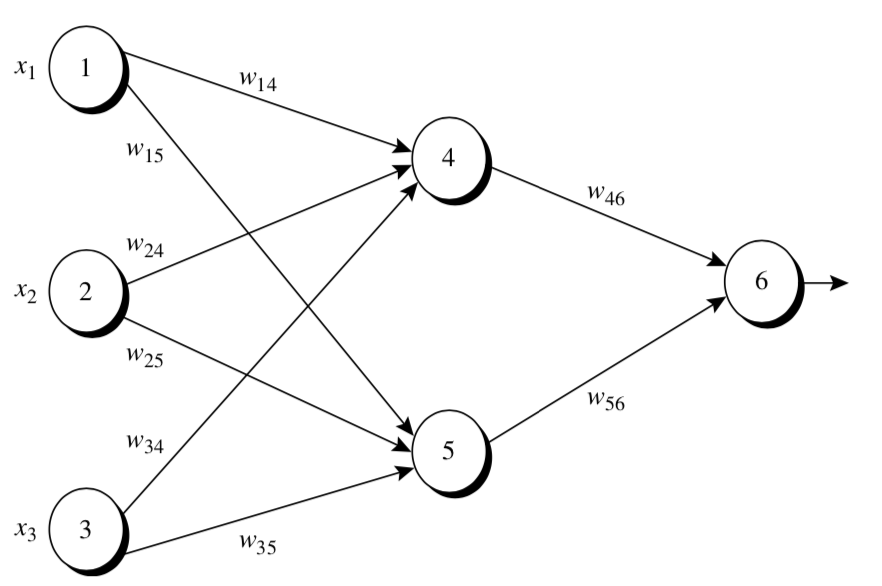

```python
from IPython.display import Image
Image("imagens/NN-Hanetal.png")
```

# Updating weights

- Calculate the delta of $w$

$$ \Delta w_{ij}=\gamma. \Delta Err_j. o_i $$

- Given
  - $\gamma = 0.9$
  - $o_1=x_1=1$
- $\Delta w_{14}=(0.9)(0.0350)(1)= 0.0315$
- Update $w$

$$w_{ij}=w_{ij} - \Delta w_{ij}$$

- Given
  - (old) $w_{14}=0.2$
- (new) $w_{14}=0.2 - 0.0315 = 0.1685$

# Training ANN > random start

- Starting values for the weights
  - Random values around zero
    - Good idea
    - Model starts linear and becomes non-linear with learning
  - Exactly zero
    - Never moves
  - Large values
    - Leads generally to poor solutions

# Training ANN > overfitting

- Overfitting
- ANN have many parameters
  - overfitting can easily happen
- To avoid overfitting stop **early**
  - use a **validation set**
  - use **weight decay** and minimize $R(\theta) + \lambda J(\theta)$ (regularization)
    - weights tend to zero with larger $\lambda$

# Training ANN > standardization

- **Scaling** of the inputs
  - Different variable scales imply different weight scales
    - this can have an effect on regularization
  - **standardization** of variables puts all on the same page
    - subtract the mean, divide by standard deviation

# Training ANN > the topology

- Before training we must define the **topology** of the network
- Number of **hidden nodes**
  - More nodes make the model more flexible / expressive
    - beware of overfitting and excessive computation time
  - Too many hidden nodes can turn to zero with appropriate regularization
  - Number can be determined with cross validation
  - But one can instead use CV to determine the regularization parameter
  - Better too many than too few

# Training ANN > hidden layers

- Each layer extracts features (abstraction)
- Multiple layers allow herarchical features
- Decision depends on **background knowledge** and experimentation
- More layers mean more parameters, higher computation time, more overfitting, etc.

# Training ANN > complexity

**Computational Considerations:**

- Given:
  - $N$ observations,
  - $p$ predictors,
  - $M$ hidden units and
  - $L$ training epochs,
- Training an ANN takes typically

$$ O(NpML) $$

# Activities

1. Check out what is the drop-out in Neural Networks
2. Compare NN with boosting on Boston and on the Wage dataset
3. Look for implementations of MLP in R or Python. What are the important parameters?

# Bibliography

**Perceptron Learning Algorithm: A Graphical Explanation Of Why It Works** Akshay L Chandra, Aug 22, 2018 https://towardsdatascience.com/perceptron-learning-algorithm-d5db0deab975

**Data Mining Concepts and Techniques** Han, Kamber & Pei, Morgan Kaufman, Wikipedia

**Backpropagation**, Wikipedia, the free encyclopedia, https://en.wikipedia.org/wiki/Backpropagation

**Backpropagation** John McGonagle, George Shaikouski, Christopher Williams https://brilliant.org/wiki/backpropagation/